# Practical Machine Learning Course Project

Anna Teplukhina | 2022-07-08

## Overview and results summary

In this project we will be using data from accelerometers on the belt, forearm, arm, and dumbell of 6 participants to analyse the way they are performing barbell lifts. They are doing this excerise correctly and incorrectly in 5 different ways.

The goal of the project is to predict the manner in which they did the exercise. This is the “classe” variable in the training set. In this project to identify the type of activity we will train multiple models and choose one that performs better than others. The chosen model will be used for predictions with the testing data set.

It has been found that the random forest model has the best performance, with 99.7% accuracy, compared to the decisions tree and gradient boosted tree models.

## Pre-modelling setup and data preparation

First, one has to load all the libraries that will be required for the following analysis and to set a seed to ensure reproducibility:

```r
library(lattice)
library(ggplot2)
library(caret)

set.seed(127)
```

There are two available data sets: training one and testing one. One can load the data and check the data structure:

```r
training <- read.csv("pml-training.csv")
testing <- read.csv("pml-testing.csv")

dim(training)
```

```
## [1] 19622   160
```

```r
dim(testing)
```

```
## [1]  20 160
```

In total, there are 160 variables and 19622/20 observations in the training/testing sets.

Before starting to develop a predictive model, it is necessary to clean the training data set and to remove unessential features, such as variables with almost zero variance and NA variables. Also, the first 7 variables (`X`, `user_name`, `raw_timestamp_part_1`, `raw_timestamp_part_2`, `cvtd_timestamp`,`new_window`, `num_window`) can be excluded too, since they do not contribute much to analysis.

```r
# Removing variables with almost zero variance
tr_nzv <- nearZeroVar(training)
training_cl <- training[,-tr_nzv]

# Removing NA variables
training_cl <- training_cl[ ,colMeans(is.na(training_cl)) < .9]

# Removing first 7 variables
training_cl <- training_cl[,-c(1:7)]

dim(training_cl)
```

```
## [1] 19622    52
```

To assess later an out-of-sample error, the training set after cleaning can be split to two subsets: sub-training and validation sets.

```r
tr_ind <- createDataPartition(y=training_cl$classe, p=0.7, list=F)
training_sub <- training_cl[tr_ind,]
training_val <- training_cl[-tr_ind,]
```

## Training of the selected models

There are three candidate models to train: decision trees (`rpart`), random forest (`rf`), gradient boosted trees (`gbm`).

For training control one can set up 3-folded cross validation:

```r
control_set <- trainControl(method='cv',number=3, verboseIter = FALSE)
```

Now one can train all the models on the same training data set `training_sub`. Coreespondig plots for each model can be found in Appendix.

```r
# Decision tree model
model_dt = train(classe~., data=training_sub, method='rpart', trControl=control_set, tuneLength=5)

# Random forest model
model_rf = train(classe~., data=training_sub, method='rf', trControl=control_set, tuneLength=5)

# Gradient boosted tree model
model_gbm = train(classe~., data=training_sub, method='gbm', trControl=control_set, tuneLength=5, verbose=FALSE)
```

## Assesment of modelling perfomance

To assess performance of the trained models, one can compare accuracy and out-of-sample error of these models. For this purpose, one can make predictions using the validation subset of the training data.

```r
# Predict with the decision tree model
pred_dt <- predict(model_dt, training_val)

# Predict with the random forest model
pred_rf <- predict(model_rf, training_val)

# Predict with the gradient boosted tree model
pred_gbm <- predict(model_gbm, training_val)
```

Accuracy and out-of-sample errors of the trained models are computed with `confusionMatrix`:

```r
# Confusion matrix for the decision tree model
confm_dt <- confusionMatrix(pred_dt, as.factor(training_val$classe))
confm_dt
```

```
## Confusion Matrix and Statistics
##
##           Reference
## Prediction    A    B    C    D    E
##          A 1215  216   21   96   58
##          B   28  491   44   20  178
##          C  391  366  855  449  450
##          D   25   65  106  399  105
##          E   15    1    0    0  291
##
## Overall Statistics
##
##                Accuracy : 0.5524
##                  95% CI : (0.5396, 0.5652)
##     No Information Rate : 0.2845
##     P-Value [Acc > NIR] : < 2.2e-16
##
##                   Kappa : 0.4362
##
##  Mcnemar's Test P-Value : < 2.2e-16
##
## Statistics by Class:
##
##                      Class: A Class: B Class: C Class: D Class: E
## Sensitivity            0.7258  0.43108   0.8333   0.4139  0.26895
## Specificity            0.9071  0.94311   0.6592   0.9388  0.99667
## Pos Pred Value         0.7565  0.64520   0.3405   0.5700  0.94788
## Neg Pred Value         0.8927  0.87354   0.9493   0.8910  0.85819
## Prevalence             0.2845  0.19354   0.1743   0.1638  0.18386
## Detection Rate         0.2065  0.08343   0.1453   0.0678  0.04945
## Detection Prevalence   0.2729  0.12931   0.4267   0.1189  0.05217
## Balanced Accuracy      0.8165  0.68709   0.7463   0.6764  0.63281
```

```r
# Confusion matrix for the random forest model
confm_rf <- confusionMatrix(pred_rf, as.factor(training_val$classe))
confm_rf
```

```
## Confusion Matrix and Statistics
##
##           Reference
## Prediction    A    B    C    D    E
##          A 1674    1    0    0    0
##          B    0 1138    1    0    0
##          C    0    0 1025   12    0
##          D    0    0    0  951    4
##          E    0    0    0    1 1078
##
## Overall Statistics
##
##                Accuracy : 0.9968
##                  95% CI : (0.995, 0.9981)
##     No Information Rate : 0.2845
##     P-Value [Acc > NIR] : < 2.2e-16
##
##                   Kappa : 0.9959
##
##  Mcnemar's Test P-Value : NA
##
## Statistics by Class:
##
##                      Class: A Class: B Class: C Class: D Class: E
## Sensitivity            1.0000   0.9991   0.9990   0.9865   0.9963
## Specificity            0.9998   0.9998   0.9975   0.9992   0.9998
## Pos Pred Value         0.9994   0.9991   0.9884   0.9958   0.9991
## Neg Pred Value         1.0000   0.9998   0.9998   0.9974   0.9992
## Prevalence             0.2845   0.1935   0.1743   0.1638   0.1839
## Detection Rate         0.2845   0.1934   0.1742   0.1616   0.1832
## Detection Prevalence   0.2846   0.1935   0.1762   0.1623   0.1833
## Balanced Accuracy      0.9999   0.9995   0.9983   0.9929   0.9980
```

```r
# Confusion matrix for the gradient boosted tree model
confm_gbm <- confusionMatrix(pred_gbm, as.factor(training_val$classe))
confm_gbm
```

```
## Confusion Matrix and Statistics
##
##           Reference
## Prediction    A    B    C    D    E
##          A 1670    1    0    0    2
##          B    4 1131    3    0    4
##          C    0    7 1021   10    2
##          D    0    0    1  948    6
##          E    0    0    1    6 1068
##
## Overall Statistics
##
##                Accuracy : 0.992
##                  95% CI : (0.9894, 0.9941)
##     No Information Rate : 0.2845
##     P-Value [Acc > NIR] : < 2.2e-16
##
##                   Kappa : 0.9899
##
##  Mcnemar's Test P-Value : NA
##
## Statistics by Class:
##
##                      Class: A Class: B Class: C Class: D Class: E
## Sensitivity            0.9976   0.9930   0.9951   0.9834   0.9871
## Specificity            0.9993   0.9977   0.9961   0.9986   0.9985
## Pos Pred Value         0.9982   0.9904   0.9817   0.9927   0.9935
## Neg Pred Value         0.9991   0.9983   0.9990   0.9968   0.9971
## Prevalence             0.2845   0.1935   0.1743   0.1638   0.1839
## Detection Rate         0.2838   0.1922   0.1735   0.1611   0.1815
## Detection Prevalence   0.2843   0.1941   0.1767   0.1623   0.1827
## Balanced Accuracy      0.9984   0.9953   0.9956   0.9910   0.9928
```

Here the models’ accuracy and out-of-sample errors are summarized:

```
##   Model Accuracy      Oserr
## 1    dt 55.24214 44.7578590
## 2    rf 99.67715  0.3228547
## 3   gbm 99.20136  0.7986406
```

The random forest mode has the highest accuracy 99.7% with 0.3% out-of-sample error. This is the best result compared to two other models and it will be used to make prediction with the testing data set.

## Predictions with the testing data set

Here predictions of the random forest model with the testing data set are presented:

```r
pred_test <- predict(model_rf, testing)
pred_test
```

```
##  [1] B A B A A E D B A A B C B A E E A B B B
## Levels: A B C D E
```

## Appendix

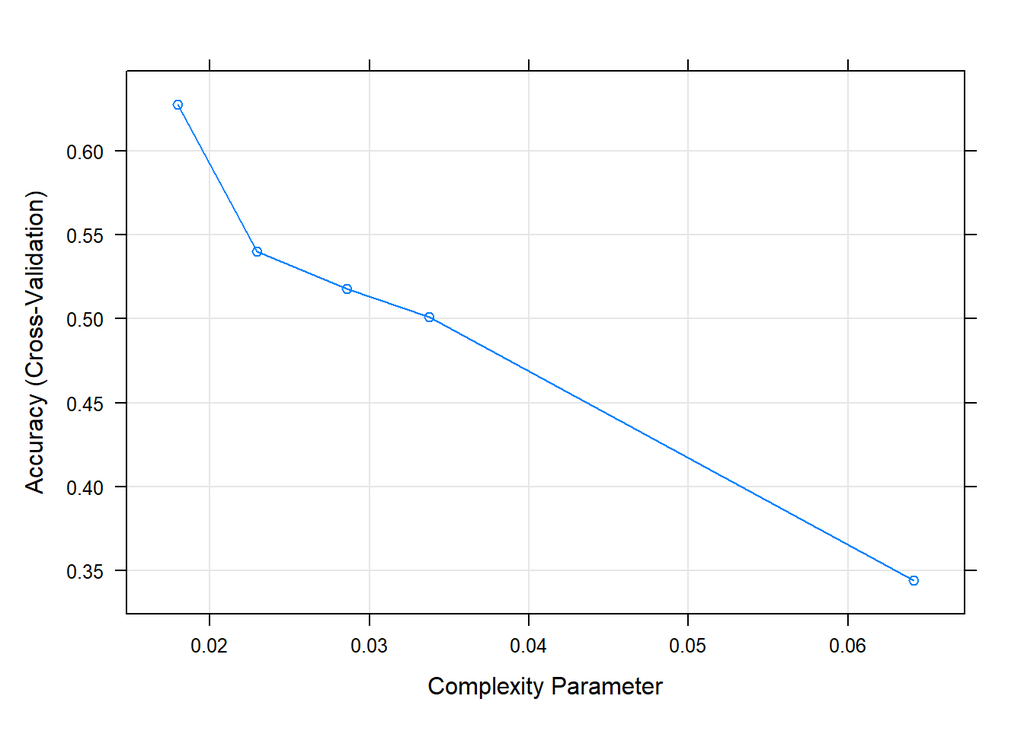

```r
# Plot for the decision tree model
plot(model_dt)
```

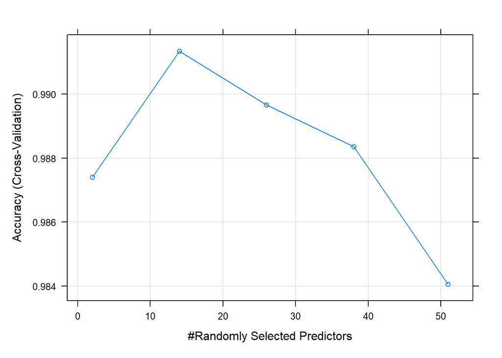

```r
# Plot for the random forest model
plot(model_rf)
```

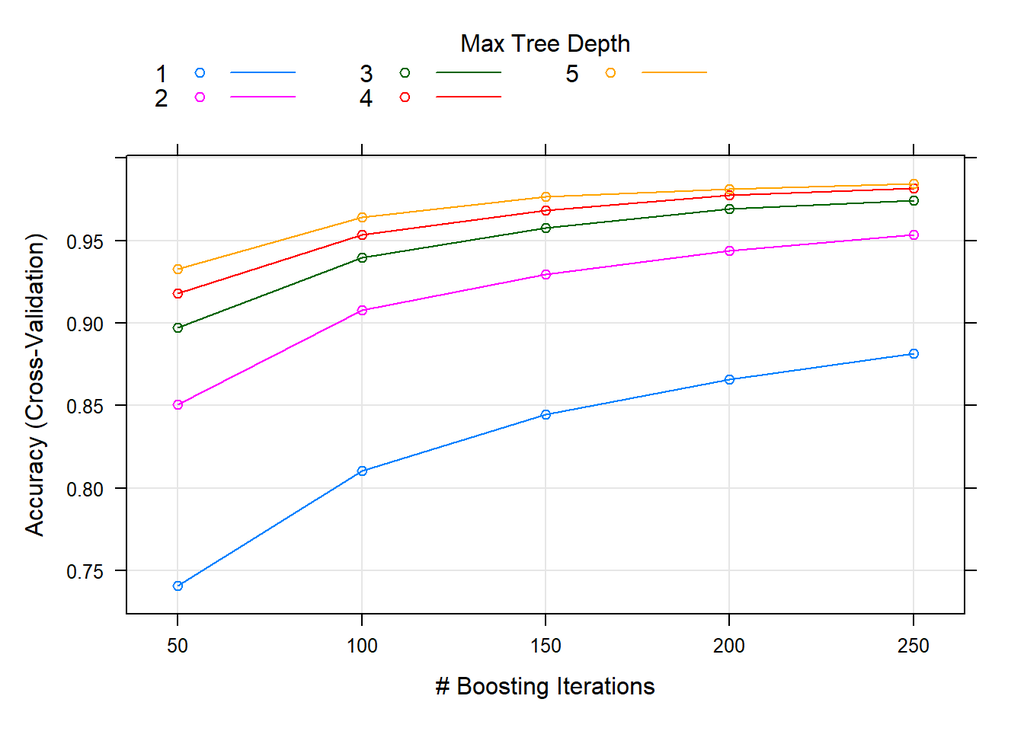

```r
# Plot for the gradient boosted tree model
plot(model_gbm)
```